# Homework: numerical linear algebra and stability issues

# Problem 1: Kriging / Gaussian process regression

## Part 1: Finishing unfinished business from lecture

Execute a command `git grep -n "sq_exp_cov <- function"` from the root directory of the git repository. Paste the output below.

```bash
# Paste the `git grep` output.
homework/numerical_stability.Rmd:25:Execute a command `git grep -n "sq_exp_cov <- function"` from the root directory of the git repository.
lecture/finite_prec_and_numerical_stability.Rmd:276:sq_exp_cov <- function(dist, range) {
lecture/finite_prec_and_numerical_stability.Rmd:303:sq_exp_cov <- function(dist, range) {
```

The grep output tells you where you can find the (failed) kriging / Gaussian process regression example in the lecture source file. Copy the synthetic observation from there (the one defined on the range $[0, 0.4]$ and $[0.6, 1.0]$).

```r
# Fill in
sq_exp_cov <- function(dist, range) {
  return(exp(-(dist / range)^2))
}

loc_obs <- c(seq(0, .4, .01), seq(.6, 1, .01))
n_obs <- length(loc_obs)

set.seed(2021)
corr_range <- .2
dist_obs <- as.matrix(dist(loc_obs))
Sigma_obs <- sq_exp_cov(dist_obs, corr_range)
y_obs <- mvrnorm(mu = rep(0, n_obs), Sigma = Sigma_obs)
```

Let’s now interpolate the missing values in $(0.4, 0.6)$ for real. To this end, we use eigen decomposition / pricipal component analysis of the GP. We can ignore the components with negligible ($\approx 0$) variance in computing $\boldsymbol{\Sigma}_{\textrm{obs}}^{-1} \boldsymbol{y}_{\textrm{obs}}$ since those components will not affect the final results of kriging/interpolation. In other words, we approximate $\boldsymbol{\Sigma}_{\textrm{obs}}^{-1}$ with $\sum_{i = 1}^k \lambda_i^{-1} \boldsymbol{u}_i \boldsymbol{u}_i^\intercal$ in computing $\boldsymbol{\Sigma}_{\textrm{obs}}^{-1} \boldsymbol{y}_{\textrm{obs}}$ for a suitably chosen number of principal components $k$. Choose $k$ to capture $99.99$% of variance in $\boldsymbol{y}_{\textrm{obs}} \sim \mathcal{N}(\boldsymbol{0}, \boldsymbol{\Sigma}_{\textrm{obs}})$.

```r
loc_new <- seq(.41, .59, .01)
# Compute the conditional mean of GP on the new locations.

# calculate eigendecomposition of Sigma_obs
eig <- eigen(Sigma_obs)

# output is a list containing eigenvalues and eigenvectors
str(eig)
```

```
## List of 2
##  $ values : num [1:82] 26.75 26.02 11.85 10.51 3.29 ...
##  $ vectors: num [1:82, 1:82] 0.0708 0.075 0.0793 0.0835 0.0877 ...
##  - attr(*, "class")= chr "eigen"
```

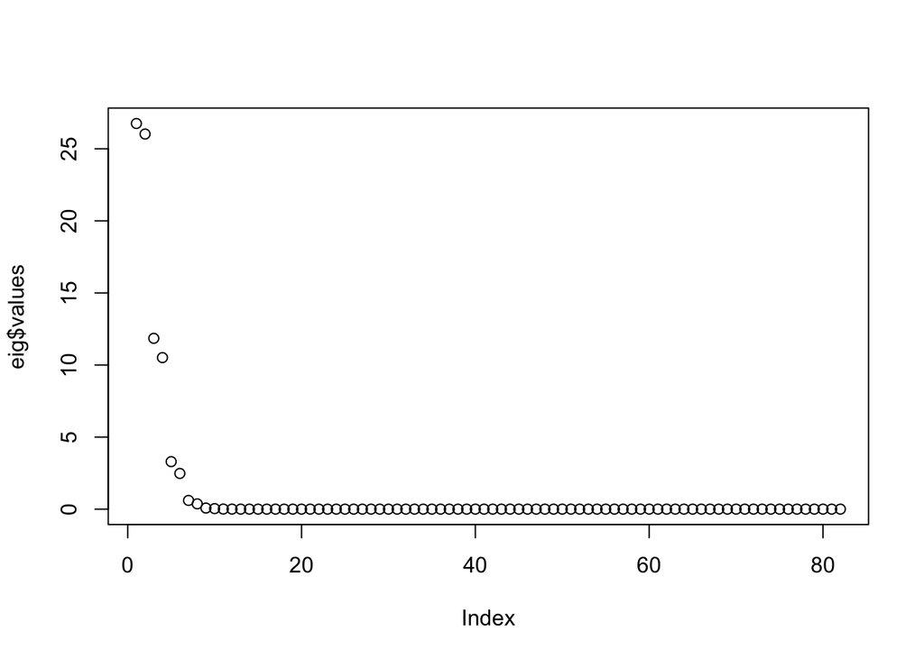

```r
# check eigenvalues are ordered
plot(eig$values)
```

```r
# select top k eigenvalues that capture 99.99% of variance
sum(eig$values)
```

```
## [1] 82
```

```r
eig_cumsum_prop <- cumsum(eig$values) / sum(eig$values)
eig_cumsum_prop
```

```
##  [1] 0.3262570 0.6436008 0.7881094 0.9163021 0.9564835 0.9866755 0.9940510
##  [8] 0.9985237 0.9994362 0.9998831 0.9999614 0.9999932 0.9999980 0.9999997
## [15] 0.9999999 1.0000000 1.0000000 1.0000000 1.0000000 1.0000000 1.0000000
## [22] 1.0000000 1.0000000 1.0000000 1.0000000 1.0000000 1.0000000 1.0000000
## [29] 1.0000000 1.0000000 1.0000000 1.0000000 1.0000000 1.0000000 1.0000000
## [36] 1.0000000 1.0000000 1.0000000 1.0000000 1.0000000 1.0000000 1.0000000
## [43] 1.0000000 1.0000000 1.0000000 1.0000000 1.0000000 1.0000000 1.0000000
## [50] 1.0000000 1.0000000 1.0000000 1.0000000 1.0000000 1.0000000 1.0000000
## [57] 1.0000000 1.0000000 1.0000000 1.0000000 1.0000000 1.0000000 1.0000000
## [64] 1.0000000 1.0000000 1.0000000 1.0000000 1.0000000 1.0000000 1.0000000
## [71] 1.0000000 1.0000000 1.0000000 1.0000000 1.0000000 1.0000000 1.0000000
## [78] 1.0000000 1.0000000 1.0000000 1.0000000 1.0000000
```

```r
eig_cumsum_prop < 0.9999
```

```
##  [1]  TRUE  TRUE  TRUE  TRUE  TRUE  TRUE  TRUE  TRUE  TRUE  TRUE FALSE FALSE
## [13] FALSE FALSE FALSE FALSE FALSE FALSE FALSE FALSE FALSE FALSE FALSE FALSE
## [25] FALSE FALSE FALSE FALSE FALSE FALSE FALSE FALSE FALSE FALSE FALSE FALSE
## [37] FALSE FALSE FALSE FALSE FALSE FALSE FALSE FALSE FALSE FALSE FALSE FALSE
## [49] FALSE FALSE FALSE FALSE FALSE FALSE FALSE FALSE FALSE FALSE FALSE FALSE
## [61] FALSE FALSE FALSE FALSE FALSE FALSE FALSE FALSE FALSE FALSE FALSE FALSE
## [73] FALSE FALSE FALSE FALSE FALSE FALSE FALSE FALSE FALSE FALSE
```

```r
# identify k
k <- sum(eig_cumsum_prop < 0.9999) + 1
# k = 11
k
```

```
## [1] 11
```

```r
# calculate approximate Sigma_obs_inv
Sigma_obs_inv_list <- vector("list", length = k)
for (i in seq_len(k)) {
  Sigma_obs_inv_list[[i]] <-
    (1 / eig$values[i]) * (eig$vectors[, i, drop = FALSE] %*% t(eig$vectors[, i, drop = FALSE]))
}
# check dimensions make sense
sapply(Sigma_obs_inv_list, dim)
```

```
##      [,1] [,2] [,3] [,4] [,5] [,6] [,7] [,8] [,9] [,10] [,11]
## [1,]   82   82   82   82   82   82   82   82   82    82    82
## [2,]   82   82   82   82   82   82   82   82   82    82    82
```

```r
# collapse list
Sigma_obs_inv <- Reduce("+", Sigma_obs_inv_list)
dim(Sigma_obs_inv)
```

```
## [1] 82 82
```

```r
# now predict new values
loc_new
```

```
##  [1] 0.41 0.42 0.43 0.44 0.45 0.46 0.47 0.48 0.49 0.50 0.51 0.52 0.53 0.54 0.55
## [16] 0.56 0.57 0.58 0.59
```

```r
dist_new <- as.matrix(dist(loc_new))
Sigma_new <- sq_exp_cov(dist_new, corr_range)
# check dimensions
n_new <- length(loc_new)
n_new
```

```
## [1] 19
```

```r
dim(dist_new)
```

```
## [1] 19 19
```

```r
dim(Sigma_new)
```

```
## [1] 19 19
```

```r
# cross covariance matrix from new to old observations
dist_all <- as.matrix(dist(c(loc_new, loc_obs)))
dist_cross <- dist_all[1:n_new, (n_new + 1):(n_new + n_obs)]
Sigma_cross <- sq_exp_cov(dist_cross, corr_range)


# predict new observations
mean_new <- rep(0, n_new)
mean_obs <- rep(0, n_obs)
y_new <- mean_new + Sigma_cross %*% Sigma_obs_inv %*% matrix(y_obs - mean_obs, ncol = 1)

y_new <- as.vector(y_new)
y_new
```

```
##  [1]  0.15806404  0.14335104  0.11419022  0.07155579  0.01697252 -0.04753798
##  [7] -0.11953267 -0.19624046 -0.27466932 -0.35172218 -0.42431623 -0.48950048
## [13] -0.54456626 -0.58714624 -0.61529779 -0.62756772 -0.62303618 -0.60133857
## [19] -0.56266564
```

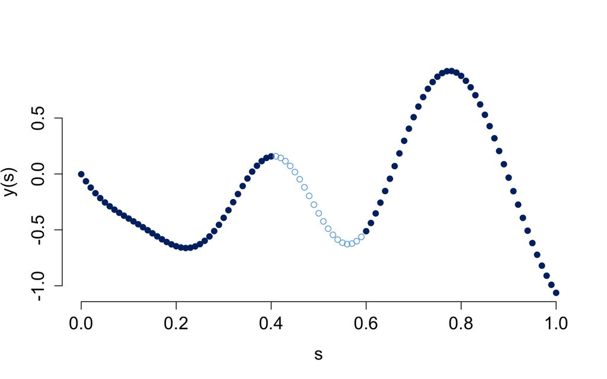

```r
solid_circle_index <- 19
plot(
  # Fill in
  x = loc_obs, y = y_obs,
  xlab="s", ylab="y(s)",
  pch=solid_circle_index,
  cex.lab=1.4, cex.axis=1.4,
  col=jhu_color$heritageBlue,
  frame.plot = F
)
points(
  # Fill in
  x = loc_new, y = y_new,
  col = jhu_color$spiritBlue
)
```